# Regresión lineal

Osmar Dominique

2025-09-10

Veamos un ejemplo con la data “iris”.

Para ver si hay una buena relación entre al menos dos variables de la base de datos, obtenemos la matriz de covarianzas o la matriz de correlaciones.

```r
cor(datos1)
```

```
##              Sepal.Length Sepal.Width Petal.Length Petal.Width
## Sepal.Length    1.0000000  -0.1175698    0.8717538   0.8179411
## Sepal.Width    -0.1175698   1.0000000   -0.4284401  -0.3661259
## Petal.Length    0.8717538  -0.4284401    1.0000000   0.9628654
## Petal.Width     0.8179411  -0.3661259    0.9628654   1.0000000
```

De la matriz, observamos que la relacion más grande que tenemos es: **ancho del pétalo** y **largo del pétalo**.

Obtengamos su diagrama de dispersión de estas dos variables.

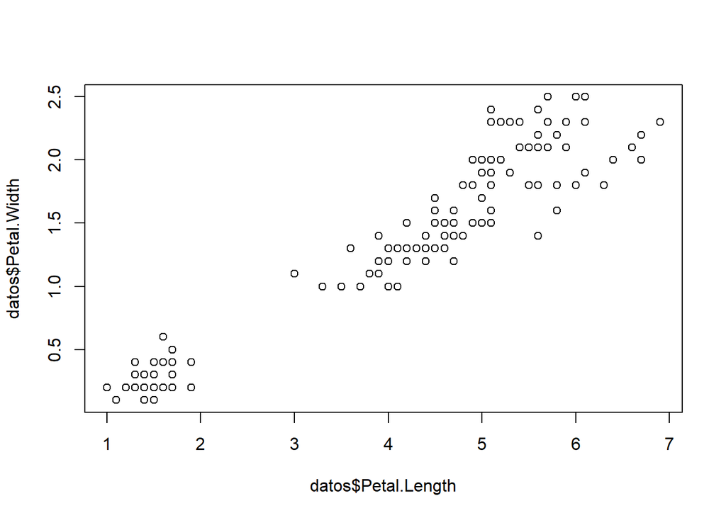

```r
plot(x = datos$Petal.Length, y = datos$Petal.Width)
```

Veamos ahora una regresión lineal entre estas variables. Para ello consideremos:

- Variable de respuesta (dependiente): ancho del pétalo.
- Variable explicativa (independiente): largo del pétalo.

Obtengamos la recta de regresión lineal de Y sobre X

```r
modelo <- lm(datos$Petal.Width ~ datos$Petal.Length, data = datos) #lineal simple
summary(modelo) #resumen del modelo
```

```
##
## Call:
## lm(formula = datos$Petal.Width ~ datos$Petal.Length, data = datos)
##
## Residuals:
##      Min       1Q   Median       3Q      Max
## -0.56515 -0.12358 -0.01898  0.13288  0.64272
##
## Coefficients:
##                     Estimate Std. Error t value Pr(>|t|)
## (Intercept)        -0.363076   0.039762  -9.131  4.7e-16 ***
## datos$Petal.Length  0.415755   0.009582  43.387  < 2e-16 ***
## ---
## Signif. codes:  0 '***' 0.001 '**' 0.01 '*' 0.05 '.' 0.1 ' ' 1
##
## Residual standard error: 0.2065 on 148 degrees of freedom
## Multiple R-squared:  0.9271, Adjusted R-squared:  0.9266
## F-statistic:  1882 on 1 and 148 DF,  p-value: < 2.2e-16
```

- Recta de regresión lineal

```r
modelo$coefficients
```

```
##        (Intercept) datos$Petal.Length
##         -0.3630755          0.4157554
```

Con los valores estimados podemos obtener la recta

$$y = -0.363076 + 0.415755*X$$

Ahora, veamos si los coeficientes del modelo son significativos. Esto lo haremos mediante pruebas de hipótesis.

En los dos p-values, obtenemos valores menores a 0.05, por lo que rechazamos H0 en favor de H1, es decir, que los dos coeficientes deben ser distintos de cero. Por lo tanto, **los dos coeficientes son significativos para el modelo**.

**Conclusión:** Como los dos coeficientes son significativos, entonces nuestro modelo sí queda representado como:

$$y = -0.363076 + 0.415755*X$$

Del resumen del modelo, obtenemos un coeficiente de determinación ($ R^2 $) de 0.9271, es decir, el modelo explica el 92.7% da la variabilidad total.

## ANOVA

Este nos servirá para decir si el modelo es significativo o no.

```r
#ANOVA en regresión lineal
anova(modelo)
```

```
## Analysis of Variance Table
##
## Response: datos$Petal.Width
##                     Df Sum Sq Mean Sq F value    Pr(>F)
## datos$Petal.Length   1  80.26  80.260  1882.5 < 2.2e-16 ***
## Residuals          148   6.31   0.043
## ---
## Signif. codes:  0 '***' 0.001 '**' 0.01 '*' 0.05 '.' 0.1 ' ' 1
```

Del ANOVA obtenemos un p-value = 2.2e-16, entonces se rechaza H0, en favor de H1, es decir, que el modelo sí es significativo.

**NOTA:** Recordemos que toda prueba de hipótesis debe contener:

H0: Hipótesis nula. H1: Hipótesis alterntiva (es lo que el investigador afirma).

Posteriormente se calcula un estadístico y se obtiene un p-value (valor-p), el cual nos dirá si se rechaza H0 o no habrá evidencia para poder echazar H0.